# Community Experiment - Trajectories PCA

Julius Hoffmann

2024-01-08

## Load packages

```r
library(tidyverse)
library(data.table)
library(ecotraj)
library(vegan)
library(ggrepel)
library(zCompositions)
library(compositions)
library(funrar)
library(flextable)
```

```r
set_flextable_defaults(
  font.size = 10, theme_fun = theme_vanilla,
  padding = 6,
  font.family = "Arial", digits = 3)
```

## Load frequency data

The file contains species frequencies from 16s rRNA amplicon sequencing.

```r
counts_16_seq<-read_csv("../Data/sequencing_counts and metadata.csv")
```

## Aim of Analysis

The aim of this analysis is to identify differences and patterns in the compositional trajectories of communities throughout the experiment. Therefore a Principal coordinate Analysis on the Aitchisons distance between communities at all sampling time points is performed. For this analysis microcosms without predators are excluded because these were sampled in less frequent intervals. We perform geometric analysis of these trajectories and estimate the speed of compositional change by calculating the segment length between data points of each microcosm on consecutive sampling days.

## Re-arranging data for trajectory analysis

First the values for prey and predatory history are re-named. Then the data of interest is selected, i.e. data from samples without predators are removed and data from day 20 of the experiment is removed because it is not complete for all samples. Columns “full_species” for the full species name and “treatment” for the combinations of predator and prey history are created. Lastly the data is brought in shape for the following analyses.

```r
frequencies <- counts_16_seq %>%
  mutate(prey_history = str_replace_all(prey_history, c("ANC" = "Anc.prey", "EVO" = "Evo.prey")),
         predator_history = str_replace_all(predator_history, c("ANC" = "Anc.predator", "EVO" = "Evo.predator")),
         replicate = str_replace_all(replicate, c("A" = "A", "C" = "B", "E" = "C"))) %>%
  filter(!predator_history == "no_predator", time_days %in% c(4,8,12,16,24,28,32,36,40,44,48,52,56,60)) %>% #sampling at day 20 not complete, thus removed from analysis
  dplyr::select(genus,species,count,replicate, prey_history, predator_history, time_days) %>%
  mutate(full_species = apply(., 1, function(x) paste(x["genus"],x["species"], sep = "_")),
         treatment = apply(., 1, function(x) paste(x["prey_history"],x["predator_history"], sep = "_"))) %>%
  dplyr::select(full_species, treatment, count,replicate, time_days) %>%
  group_by(treatment,replicate, time_days)%>%
  reframe(Species = full_species,

            count = count) %>%
  pivot_wider(id_cols = c(1,2,3), names_from = "Species", values_from = "count") %>%
  ungroup()
```

## Extract information for plot annotation

Some information is extracted or added to the data to allow for easier annotation later on.

1. each replicate is assigned a distinct number

```r
replicates <-frequencies %>%
  reframe(sites = apply(., 1, function(x) paste(x["treatment"],x["replicate"], sep = "_")),) %>%
  group_by(sites) %>%
  mutate(sites = cur_group_id()) %>%
  ungroup() %>%
  pull(sites)
```

2. Sampling time points are assigned ongoing numbers.

```r
sampling_times <- frequencies %>%
  mutate(survey = time_days) %>%
  pull(survey)
```

3. Individual names are derived for all 12 samples/microcosms.

```r
sample_names <-frequencies %>%
  filter(time_days == 4) %>%
  separate_wider_delim(treatment, delim = "_" , names = c("prey_history", "predator_history"), cols_remove = TRUE) %>%
  dplyr::select(prey_history,predator_history,replicate)
```

4. Sample names are also derived for each microcosm on each sampling day.

```r
sample_names_all <- frequencies %>%
  separate_wider_delim(treatment, delim = "_" , names = c("prey_history", "predator_history"), cols_remove = TRUE) %>%
  dplyr::select(prey_history,predator_history,replicate,time_days)
```

## Analyse Communnity Trajectories

1. First, zeros are replaced by a Bayesian-multiplicative replacement strategy that preserves the ratios between the non-zero components and amplicon counts are transformed to relative values based on the total counts per sample.

Furthermore, the amplicon-counts are then transformed as the Aitchison distance is the euclidean distance between samples of mean centred log transformed (clr) counts.

```r
trans_count_pred <- zCompositions::cmultRepl(frequencies[,4:27], output = "prop")
```

```
## No. adjusted imputations:  18
```

```r
trans_count_pred_clr <- compositions::clr(trans_count_pred)
```

2. Principal Component Analysis is performed based on the CLR transformed data (alternatively on ) equivalent to Principal Coordinate Analysis (PCoA) on Aitchisons distance).

```r
PCA <-   prcomp(trans_count_pred_clr )
```

3. Coordinates of data points in the PCoA are extracted and are assigned to the corresponding sample names with sampling days.

```r
PCA_cord <- data.frame(PCA$x) %>%
  dplyr::select(PC1, PC2)

named_PCA <- cbind(PCA_cord, sample_names_all)

named_PCA$time_days <- as.numeric(named_PCA$time_days)
```

## Visualise trajectories with ggplot

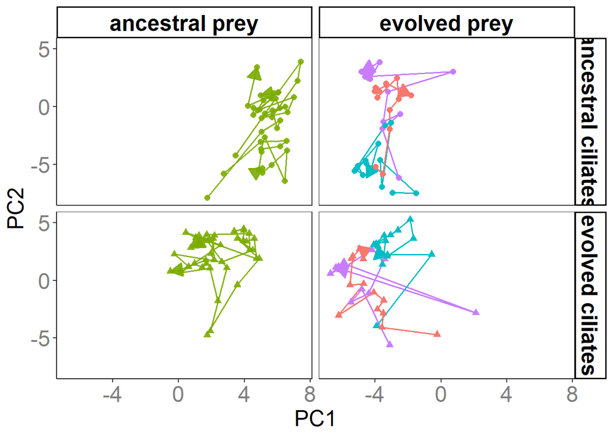

## Geometric analysis of trajectories

Further analysis can be performed either directly from the Aitchison distance matrix or from a distance matrix based on the PCoA. I am visualising the trajectories in the PCoA, so I am using the PCoA distance matrix.

1. The distance matrix is created from PCoA coordinates

```r
distance_matrix <- dist(PCA_cord)
```

2. Lengths of segments between consecutive sampling days is calculated

```r
traj_length <- trajectoryLengths(distance_matrix, sites = replicates, surveys = sampling_times )
```

## Visualise segment lengths

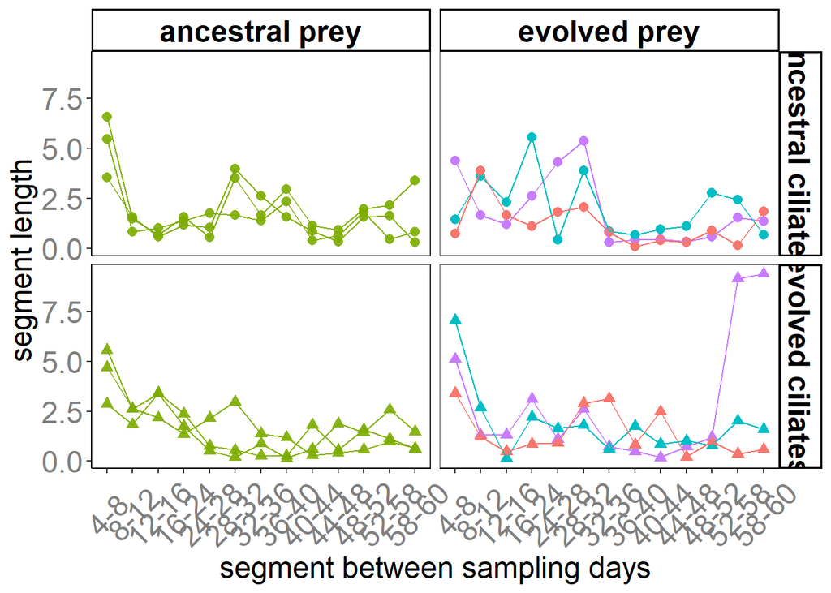

Determine directionality of trajectories

```r
traj_direct <- trajectoryDirectionality(distance_matrix, sites = replicates, surveys = sampling_times )

sites <- frequencies %>%
  reframe(sites = apply(., 1, function(x) paste(x["treatment"],x["replicate"], sep = "_")),) %>%
  group_by(sites) %>%
  group_keys


traj_direct <- cbind(sites,traj_direct )

ft_traj_direct <- flextable(traj_direct)%>%
                                colformat_double(digits = 3)
ft_traj_direct <- autofit(ft_traj_direct)

ft_traj_direct <- add_header_lines(ft_traj_direct,
  values = c("Directionality of trajectories within PCoA") )
ft_traj_direct
```

| Directionality of trajectories within PCoA sites | Directionality of trajectories within PCoA traj_direct |
| --- | --- |
| Anc.prey_Anc.predator_A | 0.328 |
| Anc.prey_Anc.predator_B | 0.377 |
| Anc.prey_Anc.predator_C | 0.472 |
| Anc.prey_Evo.predator_A | 0.451 |
| Anc.prey_Evo.predator_B | 0.464 |
| Anc.prey_Evo.predator_C | 0.405 |
| Evo.prey_Anc.predator_A | 0.558 |
| Evo.prey_Anc.predator_B | 0.313 |
| Evo.prey_Anc.predator_C | 0.540 |
| Evo.prey_Evo.predator_A | 0.384 |
| Evo.prey_Evo.predator_B | 0.388 |
| Evo.prey_Evo.predator_C | 0.618 |

```r
save_as_image(ft_traj_direct,"../Results/Directionality_Aitchison_PCA.png")
```

```
## [1] "../Results/Directionality_Aitchison_PCA.png"
```

## Investigate species impact

```r
species <- as.data.frame(trans_count_pred_clr)

species_impact <- envfit(PCA, species, perm = 999)

# extract p-values for each species
species_pvals <- species_impact$vectors$pvals %>%
  as.data.frame() %>%
  rownames_to_column("species") %>%
  dplyr::rename("pvals" = ".")

# extract coordinates for species, only keep species with p-val = 0.001
important_species <- species_impact %>%
  scores(., display = "vectors") %>%
  as.data.frame() %>%
  rownames_to_column("species") %>%
  full_join(., species_pvals, by = "species") %>%
  filter(pvals == 0.001)

colnames(important_species) <- c("species","PC1", "PC2","pvals")
named_PCA$replicate <- as.factor(named_PCA$replicate)
```

2. Coordinates of significantly impacting species are then plotted as vectors from the origin.

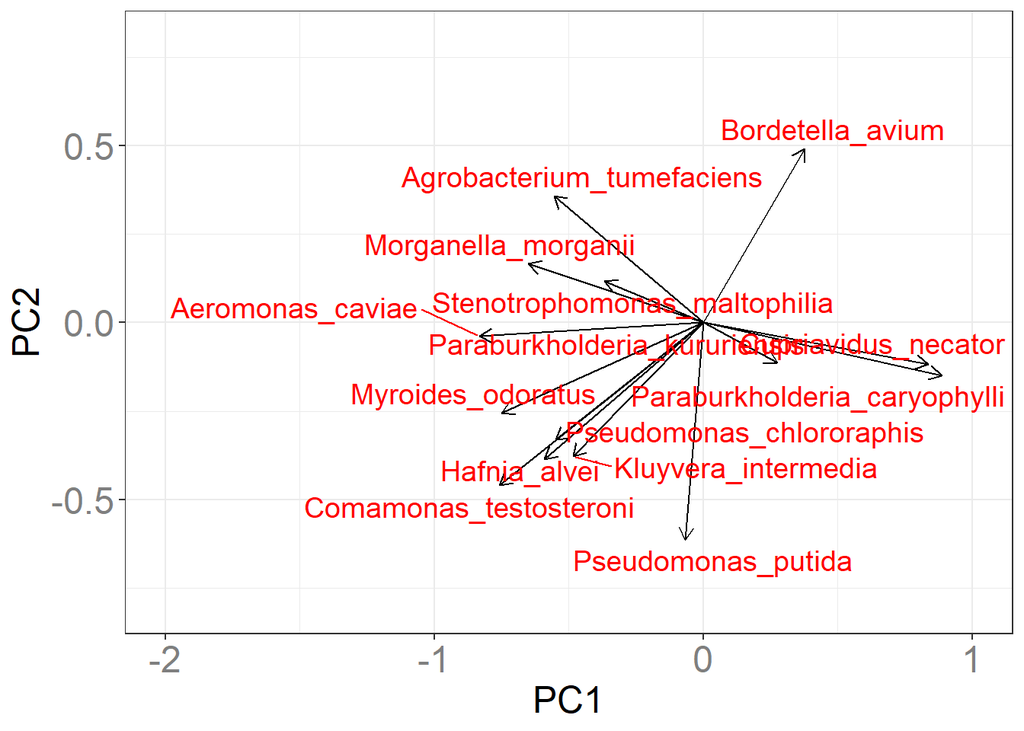

## PERMANOVA

```r
Perm_CTRL <- how(within = Within( type = "series"),
              plots = Plots(strata = treatment_variables$Replicate_unique, type = "free"),
              nperm = 999,
              observed = TRUE)
```

3. The PERMANOVA is run (here method “euclidean” is used as amplicon-counts are already clr-transformed and this is then equivalent to the Aitchison distance).

```r
distances_test <- adonis2(species ~ prey_history * predator_history  * time_days, method="euclidean", data = treatment_variables, permutations = Perm_CTRL )
distances_test
```

```
## Permutation test for adonis under reduced model
## Terms added sequentially (first to last)
## Plots: treatment_variables$Replicate_unique, plot permutation: free
## Permutation: series
## Number of permutations: 999
##
## adonis2(formula = species ~ prey_history * predator_history * time_days, data = treatment_variables, permutations = Perm_CTRL, method = "euclidean")
##                                          Df SumOfSqs      R2        F Pr(>F)
## prey_history                              1   2530.5 0.31537 105.2458  0.001
## predator_history                          1    609.6 0.07597  25.3528  0.102
## time_days                                 1    341.0 0.04250  14.1827  0.001
## prey_history:predator_history             1    528.2 0.06583  21.9688  0.093
## prey_history:time_days                    1    109.6 0.01366   4.5576  0.001
## predator_history:time_days                1     29.3 0.00365   1.2185  0.221
## prey_history:predator_history:time_days   1     28.7 0.00357   1.1920  0.240
## Residual                                160   3846.9 0.47945
## Total                                   167   8023.7 1.00000
##
## prey_history                            ***
## predator_history
## time_days                               ***
## prey_history:predator_history           .
## prey_history:time_days                  ***
## predator_history:time_days
## prey_history:predator_history:time_days
## Residual
## Total
## ---
## Signif. codes:  0 '***' 0.001 '**' 0.01 '*' 0.05 '.' 0.1 ' ' 1
```

```r
ft_PERMANOVA <- cbind(row.names(distances_test[,1:5]), distances_test[,1:5])
colnames(ft_PERMANOVA)[1] <- ("variable")
ft_PERMANOVA <- as_flextable(ft_PERMANOVA)

ft_PERMANOVA
```

| variable character | Df numeric | SumOfSqs numeric | R2 numeric | F numeric | Pr(>F) numeric |
| --- | --- | --- | --- | --- | --- |
| prey_history | 1 | 2,530.457 | 0.315 | 105.246 | 0.001 |
| predator_history | 1 | 609.565 | 0.076 | 25.353 | 0.102 |
| time_days | 1 | 340.998 | 0.042 | 14.183 | 0.001 |
| prey_history:predator_history | 1 | 528.202 | 0.066 | 21.969 | 0.093 |
| prey_history:time_days | 1 | 109.580 | 0.014 | 4.558 | 0.001 |
| predator_history:time_days | 1 | 29.297 | 0.004 | 1.219 | 0.221 |
| prey_history:predator_history:time_days | 1 | 28.660 | 0.004 | 1.192 | 0.240 |
| Residual | 160 | 3,846.928 | 0.479 |  |  |
| Total | 167 | 8,023.689 | 1.000 |  |  |

n: 9

```r
save_as_image(ft_PERMANOVA,"../Results/PERMANOVA_Aitchison_PCA.png")
```

```
## [1] "../Results/PERMANOVA_Aitchison_PCA.png"
```

```r
distance_dispersion <- betadisper(vegdist(species, method="euclidean"), factor(paste(treatment_variables$treatment,treatment_variables$time_days)))
result_dispersion <- anova(distance_dispersion)

result_dispersion
```

```
## Analysis of Variance Table
##
## Response: Distances
##            Df Sum Sq Mean Sq F value Pr(>F)
## Groups     55 144.32  2.6240  0.4441 0.9994
## Residuals 112 661.74  5.9084
```

```r
ft_dispersion <- cbind(row.names(result_dispersion[,1:5]), result_dispersion[,1:5])
colnames(ft_dispersion)[1] <- ("variable")


ft_dispersion <- as_flextable(ft_dispersion)
ft_dispersion
```

| variable character | Df integer | Sum Sq numeric | Mean Sq numeric | F value numeric | Pr(>F) numeric |
| --- | --- | --- | --- | --- | --- |
| Groups | 55 | 144.318 | 2.624 | 0.444 | 0.999 |
| Residuals | 112 | 661.736 | 5.908 |  |  |

n: 2

```r
save_as_image(ft_dispersion,"../Results/Dispersion_test_Aitchison_PCA.png")
```

```
## [1] "../Results/Dispersion_test_Aitchison_PCA.png"
```

The analysis yields a non-significant result which indicates there is no over-dispersion between groups. Thus, it is valid to perform PERMANOVA on the data.